# Exploratory Data Analysis (EDA)

```python
import pandas as pd
import numpy as np
import seaborn as sns
import matplotlib.pyplot as plt
df = pd.read_csv(r"C:\Users\vivek\Downloads\Traffic_Collisions_Open_Data_3719442797094142699 (3).csv")
df.head()
```

|  | OBJECTID | EVENT_UNIQUE_ID | OCC_DATE | OCC_MONTH | OCC_DOW | OCC_YEAR | OCC_HOUR | DIVISION | FATALITIES | INJURY_COLLISIONS | ... | NEIGHBOURHOOD_158 | LONG_WGS84 | LAT_WGS84 | AUTOMOBILE | MOTORCYCLE | PASSENGER | BICYCLE | PEDESTRIAN | x | y |
| --- | --- | --- | --- | --- | --- | --- | --- | --- | --- | --- | --- | --- | --- | --- | --- | --- | --- | --- | --- | --- | --- |
| 0 | 1 | GO-20148000028 | 1/1/2014 5:00:00 AM | January | Wednesday | 2014 | 17 | D53 | 0 | NO | ... | Mount Pleasant East (99) | -79.377616 | 43.701225 | YES | NO | NO | NO | NO | -8.836276e+06 | 5.419322e+06 |
| 1 | 2 | GO-20148004875 | 1/1/2014 5:00:00 AM | January | Wednesday | 2014 | 14 | D32 | 0 | NO | ... | Lawrence Park North (105) | -79.397589 | 43.726091 | YES | NO | NO | NO | NO | -8.838499e+06 | 5.423152e+06 |
| 2 | 3 | GO-20141260499 | 1/1/2014 5:00:00 AM | January | Wednesday | 2014 | 2 | NSA | 0 | YES | ... | NSA | 0.000000 | 0.000000 | YES | NO | NO | NO | NO | 6.327780e-09 | 5.664924e-09 |
| 3 | 4 | GO-20141260663 | 1/1/2014 5:00:00 AM | January | Wednesday | 2014 | 3 | NSA | 0 | NO | ... | NSA | 0.000000 | 0.000000 | YES | NO | NO | NO | NO | 6.327780e-09 | 5.664924e-09 |
| 4 | 5 | GO-20141261162 | 1/1/2014 5:00:00 AM | January | Wednesday | 2014 | 5 | NSA | 0 | YES | ... | NSA | 0.000000 | 0.000000 | YES | NO | NO | NO | NO | 6.327780e-09 | 5.664924e-09 |

5 rows × 23 columns

```python
df.shape
```

```
(772516, 23)
```

### Dataset Shape

The dataset contains **772,516 rows** and **23 columns**, representing a very large traffic collision record for Toronto. Each row corresponds to a unique collision event, and each column provides a specific attribute such as time of occurrence, geographic coordinates, vehicle type involvement, or severity indicators. The large number of rows indicates a high-volume, multi-year dataset, suitable for detailed trend analysis, statistical modeling, and geographic hotspot detection.

```python
df.info()
```

```
<class 'pandas.core.frame.DataFrame'>
RangeIndex: 772516 entries, 0 to 772515
Data columns (total 23 columns):
 #   Column             Non-Null Count   Dtype
---  ------             --------------   -----
 0   OBJECTID           772516 non-null  int64
 1   EVENT_UNIQUE_ID    772516 non-null  object
 2   OCC_DATE           772516 non-null  object
 3   OCC_MONTH          772516 non-null  object
 4   OCC_DOW            772516 non-null  object
 5   OCC_YEAR           772516 non-null  int64
 6   OCC_HOUR           772516 non-null  int64
 7   DIVISION           772516 non-null  object
 8   FATALITIES         772516 non-null  int64
 9   INJURY_COLLISIONS  772512 non-null  object
 10  FTR_COLLISIONS     772512 non-null  object
 11  PD_COLLISIONS      772512 non-null  object
 12  HOOD_158           772516 non-null  object
 13  NEIGHBOURHOOD_158  772516 non-null  object
 14  LONG_WGS84         772516 non-null  float64
 15  LAT_WGS84          772516 non-null  float64
 16  AUTOMOBILE         772512 non-null  object
 17  MOTORCYCLE         772512 non-null  object
 18  PASSENGER          772512 non-null  object
 19  BICYCLE            772512 non-null  object
 20  PEDESTRIAN         772512 non-null  object
 21  x                  772516 non-null  float64
 22  y                  772516 non-null  float64
dtypes: float64(4), int64(4), object(15)
memory usage: 135.6+ MB
```

```python
df.describe().T
```

|  | count | mean | std | min | 25% | 50% | 75% | max |
| --- | --- | --- | --- | --- | --- | --- | --- | --- |
| OBJECTID | 772516.0 | 3.862585e+05 | 2.230063e+05 | 1.000000e+00 | 1.931298e+05 | 3.862585e+05 | 5.793872e+05 | 7.725160e+05 |
| OCC_YEAR | 772516.0 | 2.019256e+03 | 3.414332e+00 | 2.014000e+03 | 2.016000e+03 | 2.019000e+03 | 2.022000e+03 | 2.025000e+03 |
| OCC_HOUR | 772516.0 | 1.349375e+01 | 4.978853e+00 | 0.000000e+00 | 1.000000e+01 | 1.400000e+01 | 1.700000e+01 | 2.300000e+01 |
| FATALITIES | 772516.0 | 8.595291e-04 | 3.021853e-02 | 0.000000e+00 | 0.000000e+00 | 0.000000e+00 | 0.000000e+00 | 4.000000e+00 |
| LONG_WGS84 | 772516.0 | -6.643552e+01 | 2.933867e+01 | -7.963925e+01 | -7.944490e+01 | -7.937047e+01 | -7.925881e+01 | 0.000000e+00 |
| LAT_WGS84 | 772516.0 | 3.657945e+01 | 1.615389e+01 | 0.000000e+00 | 4.364455e+01 | 4.369302e+01 | 4.375165e+01 | 4.385316e+01 |
| x | 772516.0 | -7.395568e+06 | 3.265966e+06 | -8.865400e+06 | -8.843766e+06 | -8.835480e+06 | -8.823051e+06 | 6.327780e-09 |
| y | 772516.0 | 4.536463e+06 | 2.003358e+06 | 5.664924e-09 | 5.410599e+06 | 5.418059e+06 | 5.427089e+06 | 5.442747e+06 |

## Numerical Summary Insights

The summary statistics highlight several key patterns in the dataset:

- **OBJECTID** increases sequentially from 1 to 772,516, confirming that each row uniquely represents a single collision record.
- **OCC_YEAR** ranges from 2014 to 2025, with a mean of ~2019, indicating the dataset spans over 11 years of collision data.
- **OCC_HOUR** has a mean around 13.5 (1:30 PM), and values range from 0 to 23, showing full 24-hour coverage. The quartiles (10, 14, 17) reveal that most collisions occur between late morning and early evening.
- **FATALITIES** has a mean near 0, and the max is 4, confirming that fatal collisions are extremely rare events and heavily skewed toward zero.
- **LONG_WGS84** and **LAT_WGS84** mostly reflect valid Toronto coordinates, but both have zeros, indicating some invalid or missing geographic points. These outliers require filtering before geographic analysis.
- The projected coordinates **x** and **y** show similar issues, with zero values present, which should be excluded when plotting maps.

Overall, the dataset is large, time-rich, and mostly clean, with very few extreme values except for fatalities (rare) and some invalid location coordinates (0,0).

```python
df.isna().sum()
```

```
OBJECTID             0
EVENT_UNIQUE_ID      0
OCC_DATE             0
OCC_MONTH            0
OCC_DOW              0
OCC_YEAR             0
OCC_HOUR             0
DIVISION             0
FATALITIES           0
INJURY_COLLISIONS    4
FTR_COLLISIONS       4
PD_COLLISIONS        4
HOOD_158             0
NEIGHBOURHOOD_158    0
LONG_WGS84           0
LAT_WGS84            0
AUTOMOBILE           4
MOTORCYCLE           4
PASSENGER            4
BICYCLE              4
PEDESTRIAN           4
x                    0
y                    0
dtype: int64
```

## Missing Value Analysis

The dataset is generally very complete, with no missing values in the majority of columns. Only a few binary indicator columns contain missing values:

- `INJURY_COLLISIONS` — 4 missing values
- `FTR_COLLISIONS` — 4 missing values
- `PD_COLLISIONS` — 4 missing values
- `AUTOMOBILE` — 4 missing values
- `MOTORCYCLE` — 4 missing values
- `PASSENGER` — 4 missing values
- `BICYCLE` — 4 missing values
- `PEDESTRIAN` — 4 missing values

These columns are binary (YES/NO) variables representing involvement or severity. Missing values were replaced with `"NO"` to maintain consistency, since a missing severity type usually indicates the absence of that condition. All binary columns were then converted to numeric format (0/1) for accurate modeling and correlation analysis.

These columns contain only YES or NO, meaning presence or absence of a condition.

When a value is missing (NaN), you cannot leave it blank for binary logic, so you assign "NO" because:

If the collision had an injury, the value should be YES

If data is missing, it is safer to assume NO injury rather than YES — injuries are rarely missing

Same for pedestrian, bicycle, passenger, etc.

Filling missing binary values with NO is a safe and logical assumption Prevents errors in next processing steps Ensures columns do not contain NaNs

```python
df = df.fillna("NO")
```

```python
#Convert YES/NO to 1/0 for modeling
binary_cols = ["INJURY_COLLISIONS","FTR_COLLISIONS","PD_COLLISIONS",
               "AUTOMOBILE","MOTORCYCLE","PASSENGER","BICYCLE","PEDESTRIAN"]

for col in binary_cols:
    df[col] = df[col].map({"YES":1, "NO":0})
```

UNIVARIATE ANALYSIS

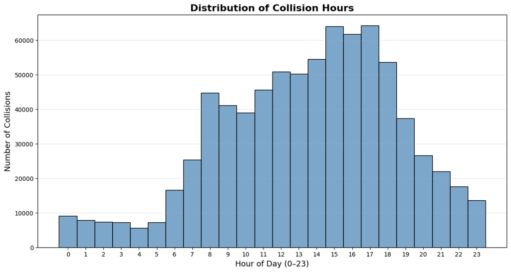

```python
#Distribution of Collision Hours
plt.figure(figsize=(14,7))

sns.histplot(
    data=df,
    x='OCC_HOUR',
    bins=24,
    discrete=True,
    kde=False,           # KDE disabled for discrete categories
    color='steelblue',
    edgecolor='black',
    alpha=0.7
)

plt.title("Distribution of Collision Hours", fontsize=16, fontweight='bold')
plt.xlabel("Hour of Day (0–23)", fontsize=13)
plt.ylabel("Number of Collisions", fontsize=13)
plt.xticks(range(0, 24))  # ensure all hour labels appear
plt.grid(axis='y', alpha=0.3)

plt.show()
```

Collisions are lowest between 12 AM–5 AM when traffic is minimal.

Sharp increase after 6 AM due to morning commute.

Peak collision hours occur between 3 PM–6 PM, aligning with evening rush hour.

Steady decline after 8 PM as road activity drops.

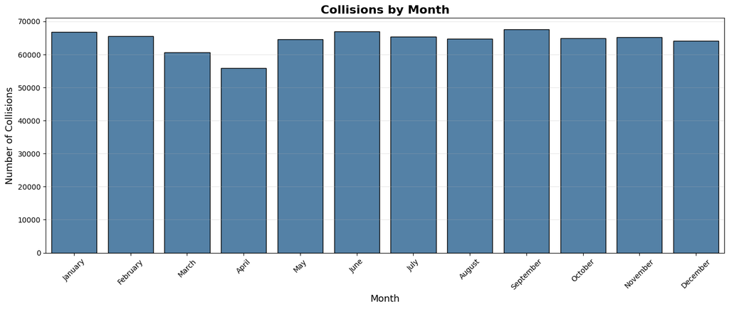

```python
#Collision Count by Month
plt.figure(figsize=(14,6))

# Ensure months are ordered Jan–Dec
month_order = [
    "January", "February", "March", "April", "May", "June",
    "July", "August", "September", "October", "November", "December"
]

sns.countplot(data=df, x='OCC_MONTH', order=month_order,
              color='steelblue', edgecolor='black')

plt.title("Collisions by Month", fontsize=16, fontweight='bold')
plt.xlabel("Month", fontsize=13)
plt.ylabel("Number of Collisions", fontsize=13)
plt.xticks(rotation=45)
plt.grid(axis='y', alpha=0.3)

plt.tight_layout()
plt.show()
```

Collisions remain fairly consistent across months with only gradual variation.

September, June, and January show the highest collision counts.

April has the lowest number of collisions.

Weather transitions and seasonal traffic patterns likely influence these fluctuations.

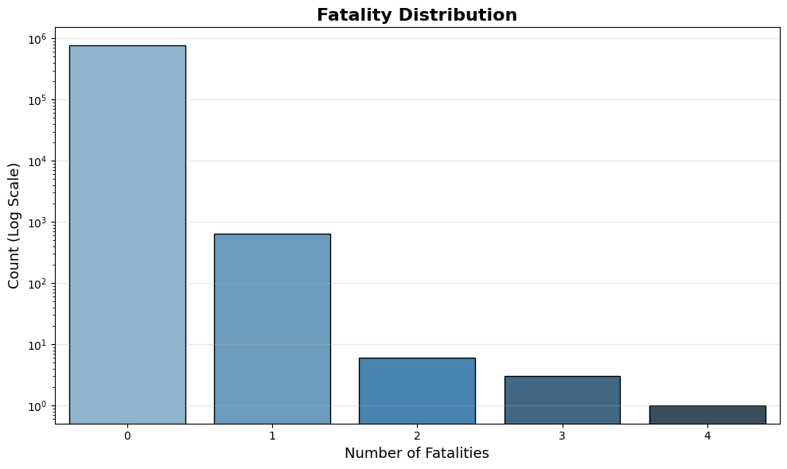

```python
#Fatalities Count
fatality_counts = df['FATALITIES'].value_counts().sort_index()

plt.figure(figsize=(10,6))
sns.barplot(
    x=fatality_counts.index,
    y=fatality_counts.values,
    palette="Blues_d",
    edgecolor="black"
)

plt.yscale("log")
plt.title("Fatality Distribution", fontsize=16, fontweight='bold')
plt.xlabel("Number of Fatalities", fontsize=13)
plt.ylabel("Count (Log Scale)", fontsize=13)
plt.grid(axis='y', alpha=0.3)
plt.tight_layout()
plt.show()
```

Most collisions involve 0 fatalities, showing fatal crashes are extremely rare.

Fatalities of 1 or more drop sharply, and counts become very small after 2–4, confirming fatal crashes are outliers.

BIVARIATE ANALYSIS (Two variables)

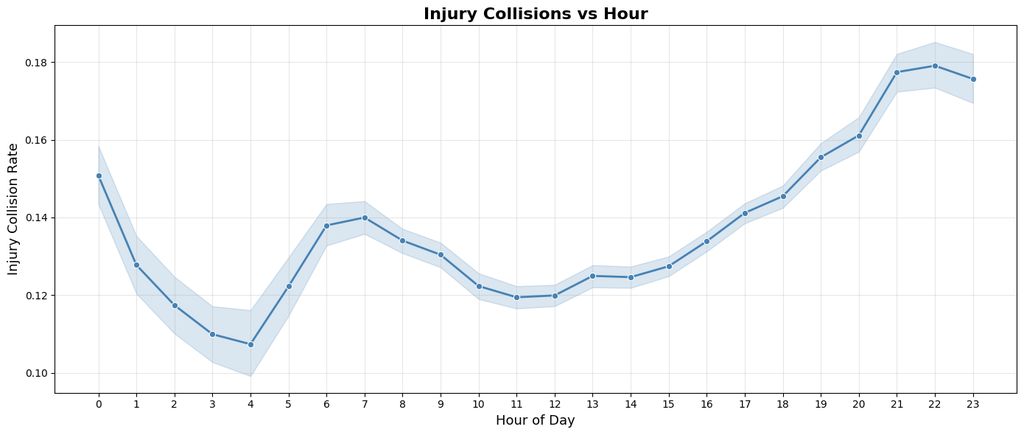

```python
#Hour vs Injuries
plt.figure(figsize=(14,6))

sns.lineplot(
    data=df,
    x='OCC_HOUR',
    y='INJURY_COLLISIONS',
    marker='o',
    linewidth=2,
    color='steelblue'
)

plt.title("Injury Collisions vs Hour", fontsize=16, fontweight='bold')
plt.xlabel("Hour of Day", fontsize=13)
plt.ylabel("Injury Collision Rate", fontsize=13)
plt.xticks(range(0,24))
plt.grid(alpha=0.3)

plt.tight_layout()
plt.show()
```

The highest injury collision proportion occurs around 21–23 hours, indicating increased nighttime risk.

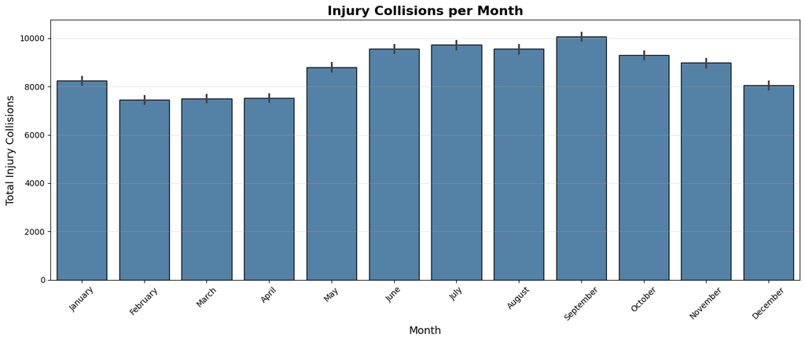

```python
#Month vs Injuries
plt.figure(figsize=(14,6))

# Correct chronological month order
month_order = [
    "January", "February", "March", "April", "May", "June",
    "July", "August", "September", "October", "November", "December"
]

sns.barplot(
    data=df,
    x='OCC_MONTH',
    y='INJURY_COLLISIONS',
    estimator=sum,
    order=month_order,
    color='steelblue',
    edgecolor='black'
)

plt.title("Injury Collisions per Month", fontsize=16, fontweight='bold')
plt.xlabel("Month", fontsize=13)
plt.ylabel("Total Injury Collisions", fontsize=13)
plt.xticks(rotation=45)
plt.grid(axis='y', alpha=0.3)
plt.tight_layout()
plt.show()
```

Injury collisions are highest in September, July, and August, reflecting heavier summer traffic and increased road activity.

The lowest injury collisions occur in February and April, likely due to reduced mobility during winter and early spring.

Overall, injuries follow a similar monthly pattern to total collisions, with moderate seasonal variation.

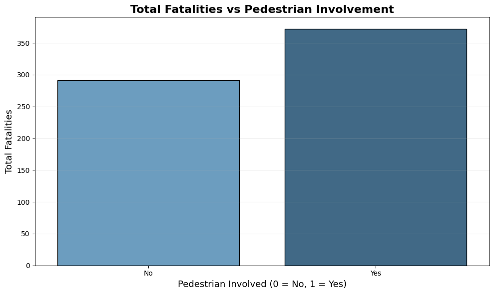

```python
#Pedestrian vs Fatalities
fatal_counts = df.groupby('PEDESTRIAN')['FATALITIES'].sum()

plt.figure(figsize=(10,6))
sns.barplot(
    x=fatal_counts.index,
    y=fatal_counts.values,
    palette="Blues_d",
    edgecolor="black"
)

plt.title("Total Fatalities vs Pedestrian Involvement", fontsize=16, fontweight='bold')
plt.xlabel("Pedestrian Involved (0 = No, 1 = Yes)", fontsize=13)
plt.ylabel("Total Fatalities", fontsize=13)
plt.xticks([0, 1], ["No", "Yes"])
plt.grid(axis='y', alpha=0.3)
plt.tight_layout()
plt.show()
```

Fatalities are higher when a pedestrian is involved compared to collisions without pedestrians.

This indicates pedestrian-related collisions are more severe and have a higher risk of resulting in death.

MULTIVARIATE ANALYSIS

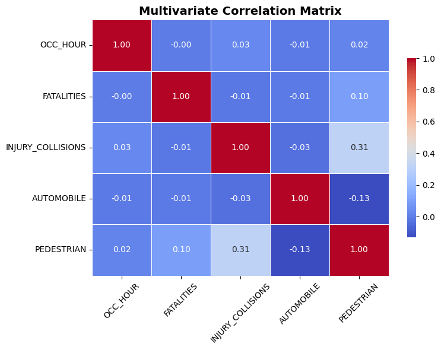

```python
#Multivariate Correlation Matrix
plt.close('all')

plt.figure(figsize=(8,6), dpi=100)

cols = ['OCC_HOUR','FATALITIES','INJURY_COLLISIONS','AUTOMOBILE','PEDESTRIAN']
corr = df[cols].corr()

sns.heatmap(
    corr,
    annot=True,
    cmap='coolwarm',
    fmt=".2f",
    linewidths=0.5,
    cbar_kws={"shrink": 0.7}
)

plt.title("Multivariate Correlation Matrix", fontsize=14, fontweight='bold')
plt.xticks(rotation=45)
plt.yticks(rotation=0)
plt.tight_layout()
plt.show()
```

All correlations are very weak, meaning these variables do not strongly predict each other.

A small positive correlation exists between PEDESTRIAN and INJURY_COLLISIONS (0.31), indicating pedestrian-involved crashes are more likely to result in injuries.

AUTOMOBILE has a weak negative relationship (–0.13) with PEDESTRIAN, showing vehicle-only collisions rarely involve pedestrians.

Hour of collision has no meaningful correlation with severity variables.

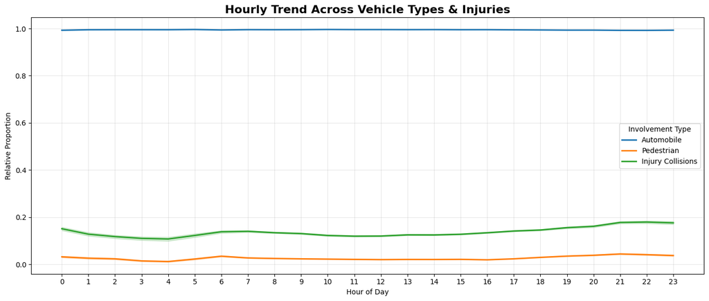

```python
#Hourly Trend Across Vehicle Types & Injuries
plt.figure(figsize=(14,6))

sns.lineplot(data=df, x='OCC_HOUR', y='AUTOMOBILE', label="Automobile", linewidth=2)
sns.lineplot(data=df, x='OCC_HOUR', y='PEDESTRIAN', label="Pedestrian", linewidth=2)
sns.lineplot(data=df, x='OCC_HOUR', y='INJURY_COLLISIONS', label="Injury Collisions", linewidth=2)

plt.title("Hourly Trend Across Vehicle Types & Injuries", fontsize=16, fontweight='bold')
plt.xlabel("Hour of Day")
plt.ylabel("Relative Proportion")
plt.legend(title="Involvement Type")
plt.xticks(range(0,24))
plt.grid(alpha=0.3)
plt.tight_layout()

plt.show()
```

Automobile involvement stays consistently high all day, showing cars dominate most collisions regardless of hour.

Pedestrian involvement remains very low throughout the day, with a minor increase in late evening.

Injury collision rates rise steadily after 6 PM, peaking around 21–23 hours, indicating nighttime crashes are more severe.

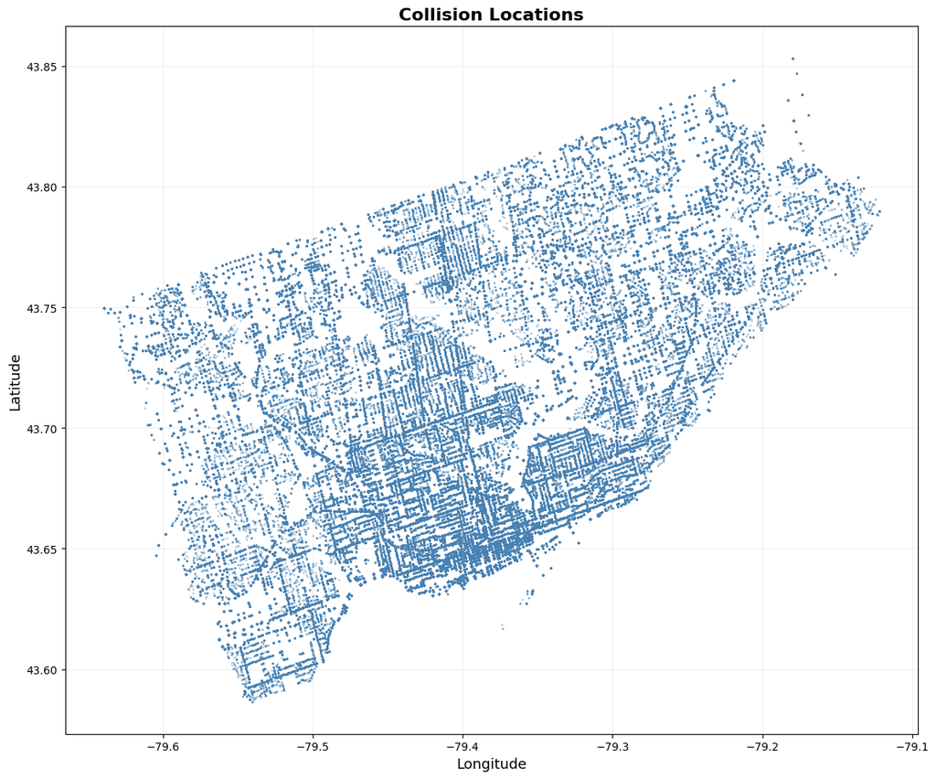

```python
#GEOGRAPHIC SCATTER
df_valid = df[(df['LONG_WGS84'] != 0) & (df['LAT_WGS84'] != 0)]

plt.figure(figsize=(12,10))
plt.scatter(
    df_valid['LONG_WGS84'],
    df_valid['LAT_WGS84'],
    s=1.5,
    alpha=0.25,
    color='steelblue'
)

plt.title("Collision Locations", fontsize=16, fontweight='bold')
plt.xlabel("Longitude", fontsize=13)
plt.ylabel("Latitude", fontsize=13)
plt.grid(alpha=0.2)
plt.tight_layout()
plt.show()
```

Collisions are heavily concentrated in the downtown core and central road network, where traffic density is highest.

Outer areas of Toronto show lighter, more scattered collision patterns, reflecting lower traffic volume.

The map forms the recognizable outline of Toronto, confirming accurate GPS data coverage.